# EDA on Kickstarter Projects

## Description :

Crowdfunding has become one of the main sources of initial capital for small businesses and start-up companies that are looking to launch their first products. Websites like Kickstarter and Indiegogo provide a platform for millions of creators to present their innovative ideas to the public. This is a win-win situation where creators could accumulate initial fund while the public get access to cutting-edge prototypical products that are not available in the market yet.

The dataset contain data on 379K projects started on Kickstarter between 2009-2018.

```
## Observations: 378,661
## Variables: 15
## $ ID               <int> 1000002330, 1000003930, 1000004038, 100000754...
## $ name             <fct> The Songs of Adelaide & Abullah, Greeting Fro...
## $ category         <fct> Poetry, Narrative Film, Narrative Film, Music...
## $ main_category    <fct> Publishing, Film & Video, Film & Video, Music...
## $ currency         <fct> GBP, USD, USD, USD, USD, USD, USD, USD, USD, ...
## $ deadline         <fct> 2015-10-09, 2017-11-01, 2013-02-26, 2012-04-1...
## $ goal             <dbl> 1000, 30000, 45000, 5000, 19500, 50000, 1000,...
## $ launched         <fct> 2015-08-11 12:12:28, 2017-09-02 04:43:57, 201...
## $ pledged          <dbl> 0.00, 2421.00, 220.00, 1.00, 1283.00, 52375.0...
## $ state            <fct> failed, failed, failed, failed, canceled, suc...
## $ backers          <int> 0, 15, 3, 1, 14, 224, 16, 40, 58, 43, 0, 100,...
## $ country          <fct> GB, US, US, US, US, US, US, US, US, US, CA, U...
## $ usd.pledged      <dbl> 0.00, 100.00, 220.00, 1.00, 1283.00, 52375.00...
## $ usd_pledged_real <dbl> 0.00, 2421.00, 220.00, 1.00, 1283.00, 52375.0...
## $ usd_goal_real    <dbl> 1533.95, 30000.00, 45000.00, 5000.00, 19500.0...
```

### Variable Description

- **name** : name of project
- **category** : sub category
- **main_category** : category of campaign
- **currency** : currency used to support
- **deadline** : deadline for crowdfunding
- **goal** : fundraising goal
- **launched** : date launched
- **pledged** : amount pledged by crowd
- **state** : current condition the project is in
- **backers** : number of backers
- **country** : country pledged from
- **usd pledged** : amount of money pledged
- **usd_pledged_real** : conversion in US dollars of the pledged column
- **usd_goal_real** : conversion in US dollars of the goal column

```
##           ID                                                       name
## 1 1000002330                            The Songs of Adelaide & Abullah
## 2 1000003930              Greeting From Earth: ZGAC Arts Capsule For ET
## 3 1000004038                                             Where is Hank?
## 4 1000007540          ToshiCapital Rekordz Needs Help to Complete Album
## 5 1000011046 Community Film Project: The Art of Neighborhood Filmmaking
## 6 1000014025                                       Monarch Espresso Bar
##         category main_category currency   deadline  goal
## 1         Poetry    Publishing      GBP 2015-10-09  1000
## 2 Narrative Film  Film & Video      USD 2017-11-01 30000
## 3 Narrative Film  Film & Video      USD 2013-02-26 45000
## 4          Music         Music      USD 2012-04-16  5000
## 5   Film & Video  Film & Video      USD 2015-08-29 19500
## 6    Restaurants          Food      USD 2016-04-01 50000
##              launched pledged      state backers country usd.pledged
## 1 2015-08-11 12:12:28       0     failed       0      GB           0
## 2 2017-09-02 04:43:57    2421     failed      15      US         100
## 3 2013-01-12 00:20:50     220     failed       3      US         220
## 4 2012-03-17 03:24:11       1     failed       1      US           1
## 5 2015-07-04 08:35:03    1283   canceled      14      US        1283
## 6 2016-02-26 13:38:27   52375 successful     224      US       52375
##   usd_pledged_real usd_goal_real
## 1                0       1533.95
## 2             2421      30000.00
## 3              220      45000.00
## 4                1       5000.00
## 5             1283      19500.00
## 6            52375      50000.00
```

It looks good for the first five rows, let’s check if there is any NA vaules in the dataset.

### Data Cleaning

```
##               ID             name         category    main_category
##                0                0                0                0
##         currency         deadline             goal         launched
##                0                0                0                0
##          pledged            state          backers          country
##                0                0                0                0
##      usd.pledged usd_pledged_real    usd_goal_real
##             3797                0                0
```

Only usd.pledged has missing values, we can remove that entire column becase we already have usd_pledged_real column and I will also remove goal and pledged column as they already exists and also the currency column since, all the currency is already convereted into USD.

# Univariate Plots Section

### Most popular Main Category

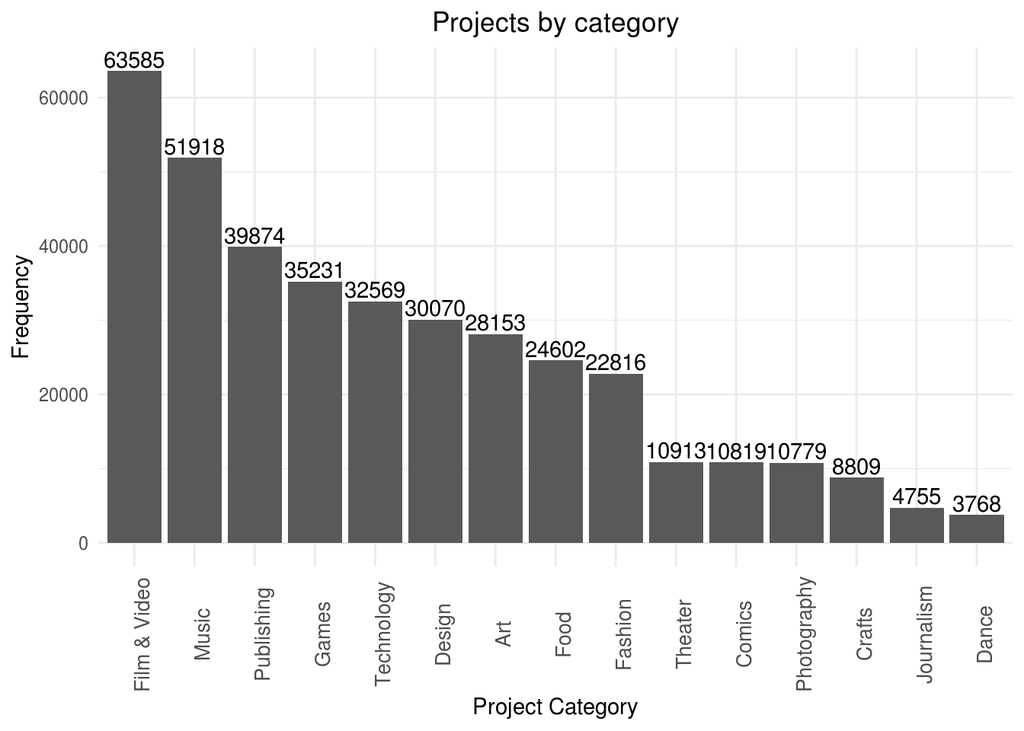

Flim & Video appears to be the most popular category and Dance the least popular.

### Most popular Sub Category

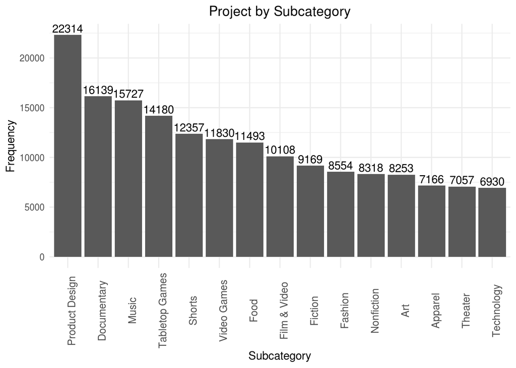

### Average Pledge and Goal amount

```
##     Min.  1st Qu.   Median     Mean  3rd Qu.     Max.
##        0       31      624     9059     4050 20338986
```

```
##      Min.   1st Qu.    Median      Mean   3rd Qu.      Max.
##         0      2000      5500     45454     15500 166361391
```

### Distribution of USD Pledged

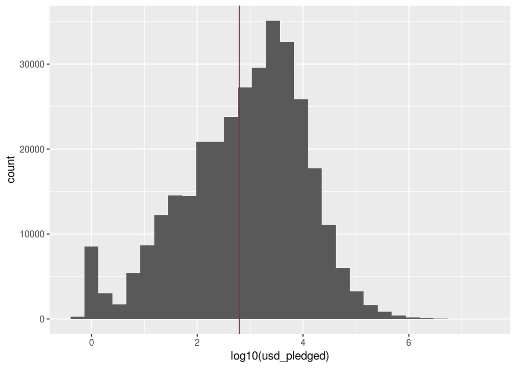

### Distribution of USD Goal

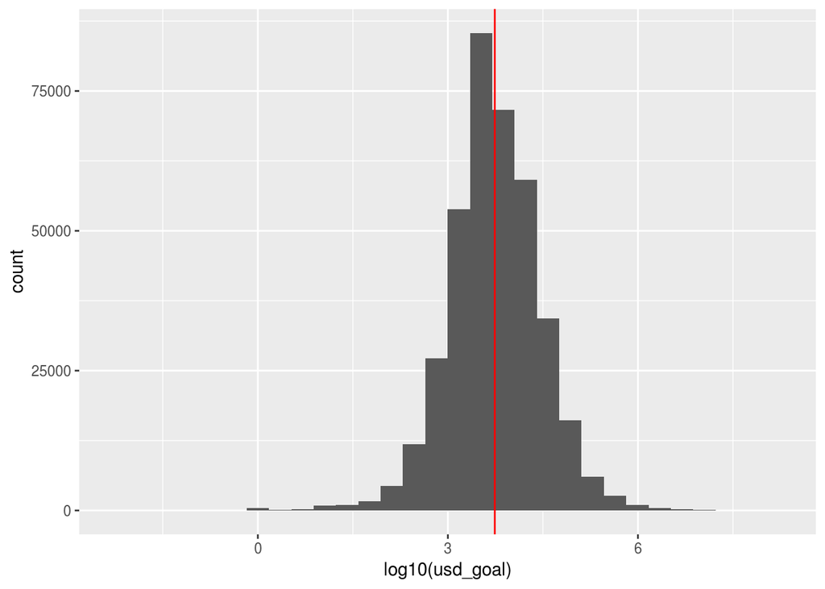

This plot is normally distributed, 3.5 is the median, there are very less projects with higher goal, maximum number of projects are in the median range.

### Number of backers

```
##     Min.  1st Qu.   Median     Mean  3rd Qu.     Max.
##      0.0      2.0     12.0    105.6     56.0 219382.0
```

The median of backers is 12 and mean is 105.6 while max is 219382, there is a huge gap between these it’s better to plot a graph as check it out.

### Distrib ution of backers

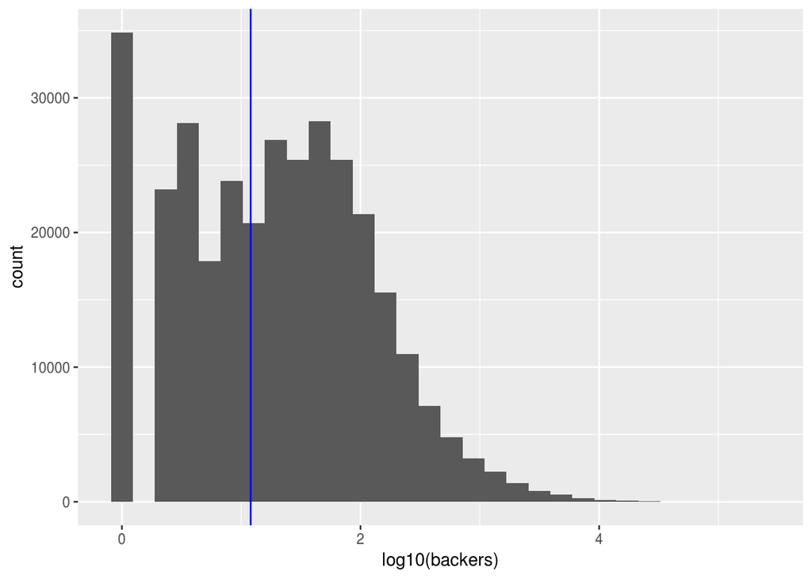

### Number of projects by year

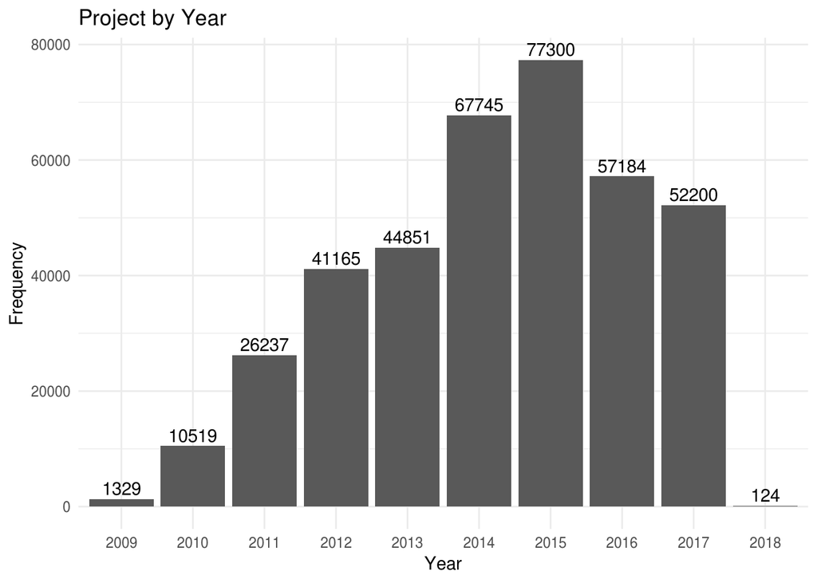

Kickstarter started in 2009 and we have the data till Janauary of 2018 and 2015 had the higgest number of projects and in 2016 it decrease by 20k and it also decreased in 2017, Acoording to Entrepreneur.com startup failure rate has been increased by 50% over few years and this might be one of the reason why we see the decrease in projects on Kickstarter.

### Number of projects by country.

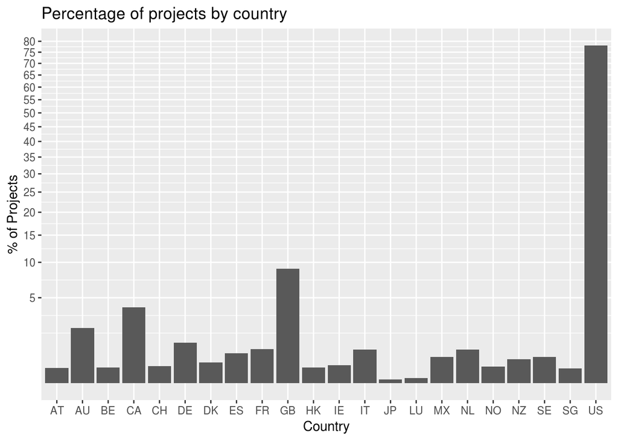

Since these countries are in abbreivated form let’s plot it in a map and check out!

### Map Plot

```
## 22 codes from your data successfully matched countries in the map
## 0 codes from your data failed to match with a country code in the map
## 220 codes from the map weren't represented in your data
```

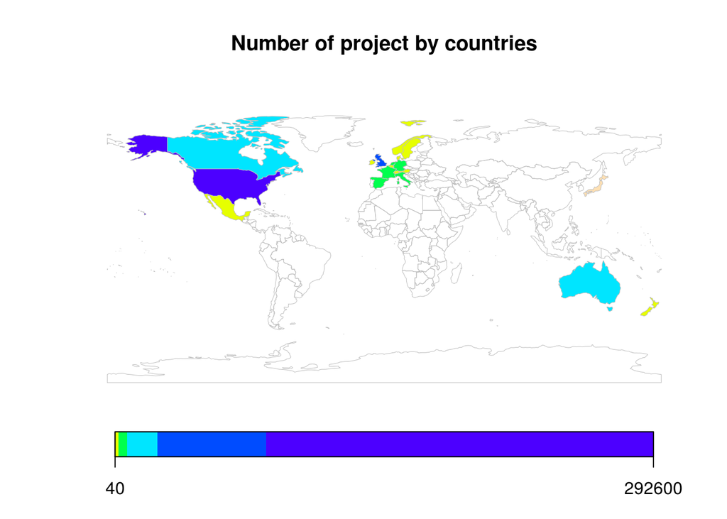

### State of the project

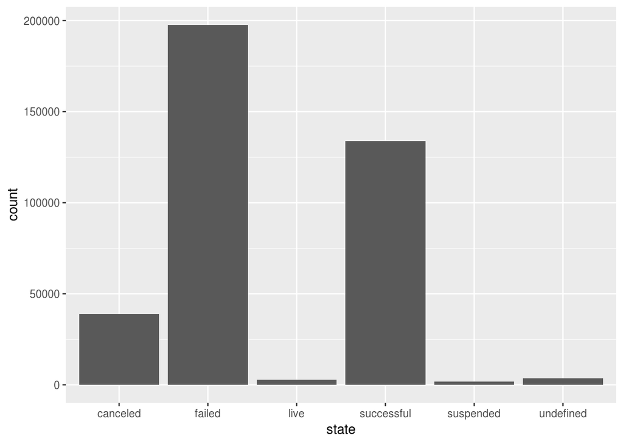

### Success Rate

```
##
##   canceled     failed       live successful  suspended  undefined
## 10.2410864 52.2153060  0.7391836 35.3762336  0.4875073  0.9406831
```

35% of projects are successful, over 52% of projects have failed, less than 1% of projects are suspended or undefined, around 10% of projects have been cancelled and surprisingly less than 1% of projects are live and as we already know that since, 2016 the number of projects per year is been decreasing.

# Univariate Analysis

### What is the structure of your dataset?

There are 378661 observations with 11 variables (ID, Name, category, main_category, deadline, launched, state, backers, country, usd_pledged, usd_goal). The variables category, main_category, state, country are factor variables.

### What is/are the main feature(s) of interest in your dataset?

The main features are state, usd_pledged, usd_goal and backers I’d like to know what deteremines the state of a project, the ratio of amount pledged and goal, the relation between amount pledged and number of backers to name a few.

### What other features in the dataset do you think will help support your?

Category, main_category, launched and country can also help in deteremining the state and amount pledged of the project.

### Did you create any new variables from existing variables in the dataset?

No, But I did remove few variables that I wasn’t going to use in this analysis.

### Of the features you investigated, were there any unusual distributions?

Yes, while plotting the number of projects by country since, US has almost 80% of the projects it was hard to identify the number of projects by other countries so I took a percentage of it and used scale_y_sqrt() with breaks to clearly find the percentage of projects by the other countries. I did the same for usd_pledged and usd_goal but with log10()

# Bivariate Plots Section

### Total amount pledged by category

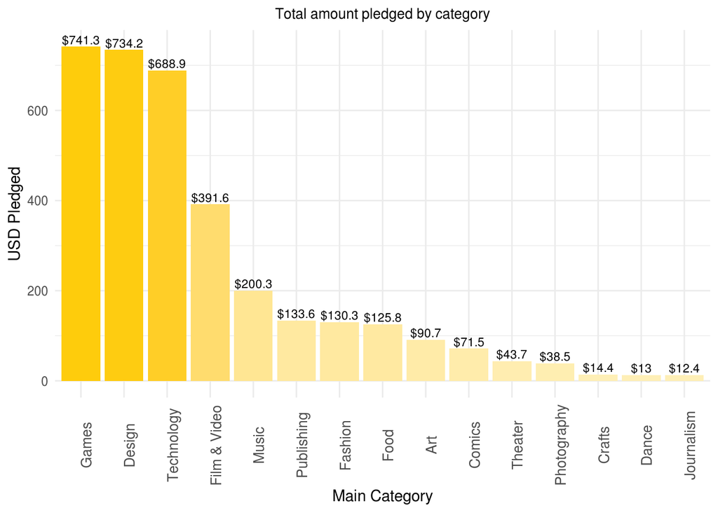

Games and design have the highes pledged amount whereas Dance and Journalism have the least, the number of backers are also an important factor, will find out the average amount pledged per backer for each category in Multivariate analysis.

### Number of Successful project by main category

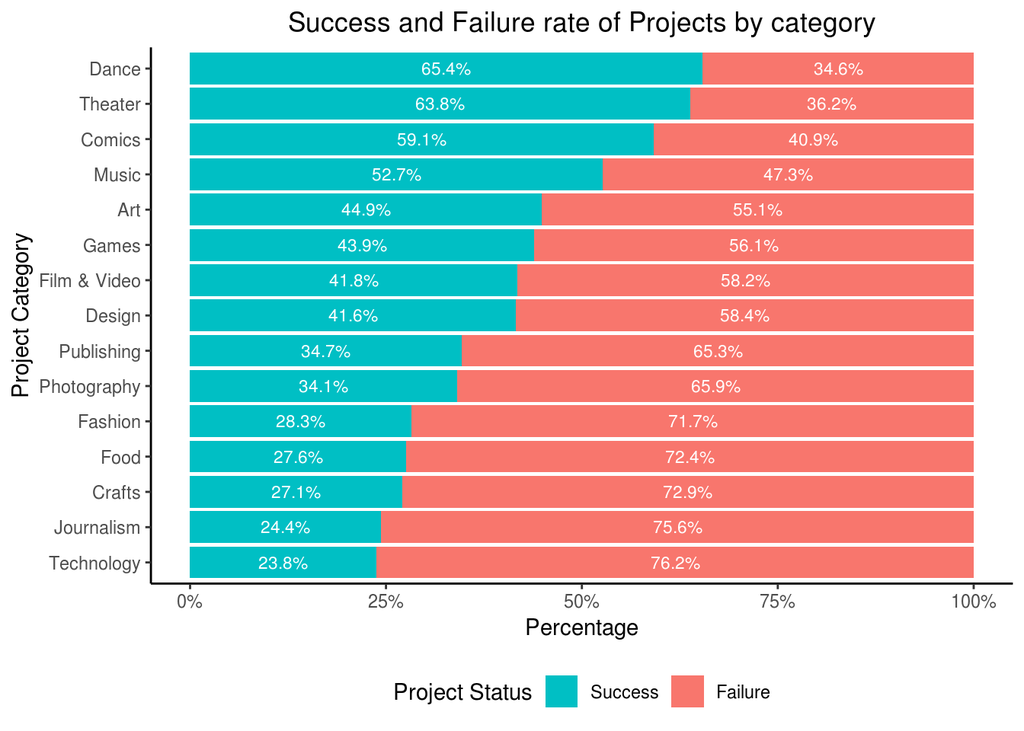

Dance and Theater has high success rate eventhough they are not at the top when it comes to funding, one of the reasons maybe beacue of the low risk involved, Journalism and Technology has a high failure rate. One of the reasons for failure of journalism might be because younger generation depending on social networks for news. Reason for high failure rate of technology might be because it has a higher risk and developing something within a give time and cost is not that feasible.

### Relation between amount pledged and number of backers

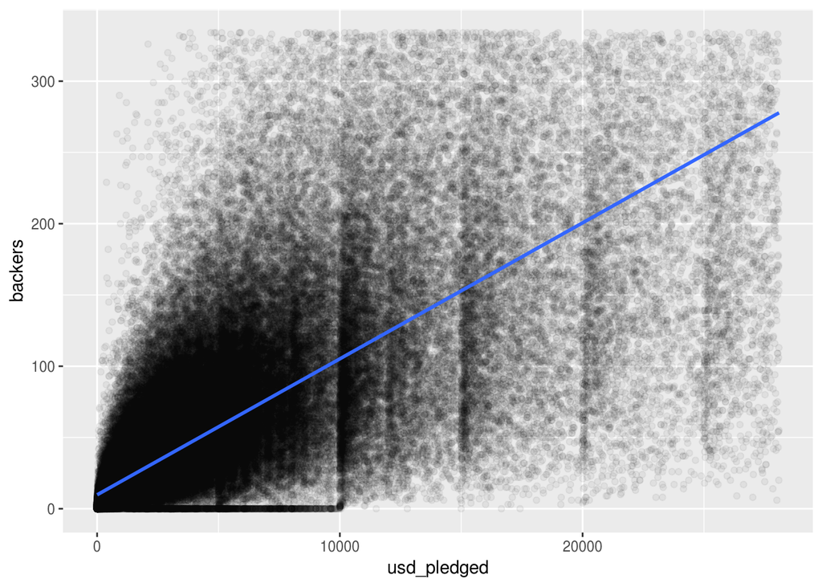

Let’s find the correlation between these two variables

```
##
##  Pearson's product-moment correlation
##
## data:  ks$usd_pledged and ks$backers
## t = 703.18, df = 378660, p-value < 2.2e-16
## alternative hypothesis: true correlation is not equal to 0
## 95 percent confidence interval:
##  0.7511547 0.7539174
## sample estimates:
##       cor
## 0.7525394
```

There is a strong correlation between these two variables.

### Success rate of projects by year

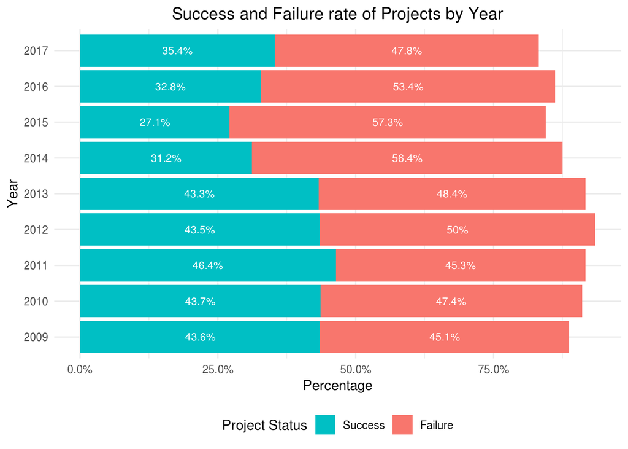

### Top projects with highest set goals

|  | name | category | state | usd_goal |
| --- | --- | --- | --- | --- |
| 47804 | FUCK Potato Salad. Paleo Potato Brownies! | Food | failed | 166361391 |
| 196532 | A Celtic Lovestory | Drama | failed | 151395870 |
| 367929 | Hydroponic’s Skyscraper(un gratte-ciel hydroponique)e-solar | Technology | failed | 110169772 |
| 222209 | DER NEANDERTALER (Kinofilm mit Starbesetzung in 3D) | Movie Theaters | failed | 107369868 |
| 226162 | Kitchen from Austria in Switzerland | Restaurants | failed | 104057190 |
| 23470 | Help me start a fair media company, Trump Media | Video | failed | 100000000 |
| 33085 | Sage: Warrior Of The Fallen Gods (Movie) | Fantasy | failed | 100000000 |
| 55010 | Kybernan Holographic Gaming Network | Video Games | failed | 100000000 |
| 72776 | Art Is Fabulous | Art | failed | 100000000 |
| 72991 | Wax Apple | Documentary | failed | 100000000 |
| 77677 | Bring back Pontiac | Technology | failed | 100000000 |
| 145944 | Let’s prove the earth is FLAT! (Suspended) (Suspended) | Video | suspended | 100000000 |
| 158460 | The Return Of The Bell Witch Movie | Shorts | failed | 100000000 |
| 160292 | The Book on Comedy 10 GABAGILLTRILLBILLIOPLEXIAN!!!!!!!!!!!! | Comics | failed | 100000000 |
| 211027 | Virtual Reality Playground in Buffalo, NY | Live Games | failed | 100000000 |
| 212542 | A Billion Pixels… | Web | failed | 100000000 |
| 213341 | Animal - The Bear Life Journey | Painting | failed | 100000000 |
| 214788 | Is Anyone Out There ? | Technology | failed | 100000000 |
| 223363 | The Time Jumper | Science Fiction | canceled | 100000000 |
| 257519 | Peace | Film & Video | failed | 100000000 |

### Top Successful projects

|  | name | category | state | usd_goal |
| --- | --- | --- | --- | --- |
| 355331 | Elite: Dangerous | Video Games | successful | 2015609 |
| 89482 | Bring Back MYSTERY SCIENCE THEATER 3000 | Television | successful | 2000000 |
| 134463 | Camelot Unchained | Video Games | successful | 2000000 |
| 148586 | The Veronica Mars Movie Project | Narrative Film | successful | 2000000 |
| 171323 | WISH I WAS HERE | Narrative Film | successful | 2000000 |
| 368574 | Shenmue 3 | Video Games | successful | 2000000 |
| 324292 | Blue Mountain State: The Movie | Narrative Film | successful | 1500000 |
| 111637 | The Newest Hottest Spike Lee Joint | Narrative Film | successful | 1250000 |
| 337373 | The Bards Tale IV | Video Games | successful | 1250000 |
| 141639 | Obduction | Video Games | successful | 1100000 |
| 272925 | Project Eternity | Video Games | successful | 1100000 |
| 30719 | Shroud of the Avatar: Forsaken Virtues | Video Games | successful | 1000000 |
| 37515 | Pathfinder Online: A Fantasy Sandbox MMO | Video Games | successful | 1000000 |
| 189800 | ARKYD: A Space Telescope for Everyone | Space Exploration | successful | 1000000 |
| 216630 | Pebble 2, Time 2 + All-New Pebble Core | Product Design | successful | 1000000 |
| 292245 | Bring Reading Rainbow Back for Every Child, Everywhere! | Web | successful | 1000000 |
| 6666 | OUYA: A New Kind of Video Game Console | Gaming Hardware | successful | 950000 |
| 51512 | LUNAR MISSION ONE: A new lunar mission for everyone. | Space Exploration | successful | 938879 |
| 61795 | System Shock | Video Games | successful | 900000 |
| 82884 | Armikrog. | Video Games | successful | 900000 |

Comparing the goals of these projects with the most ambitions one we can clearly see that there is a huge gap, and Games, Design, technology are the top categries to get funded.

Let’s examine the distribution of USD Goal for each category.

### Distribution of USD Goal for Main Category

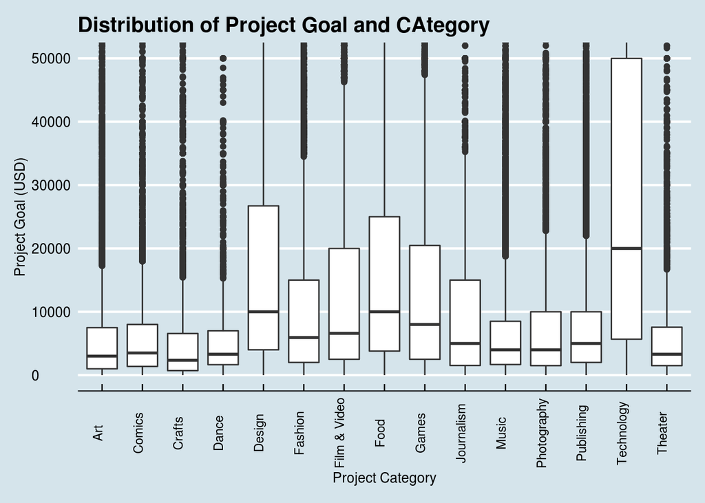

### Distribution of USD Goal and USD Pledge

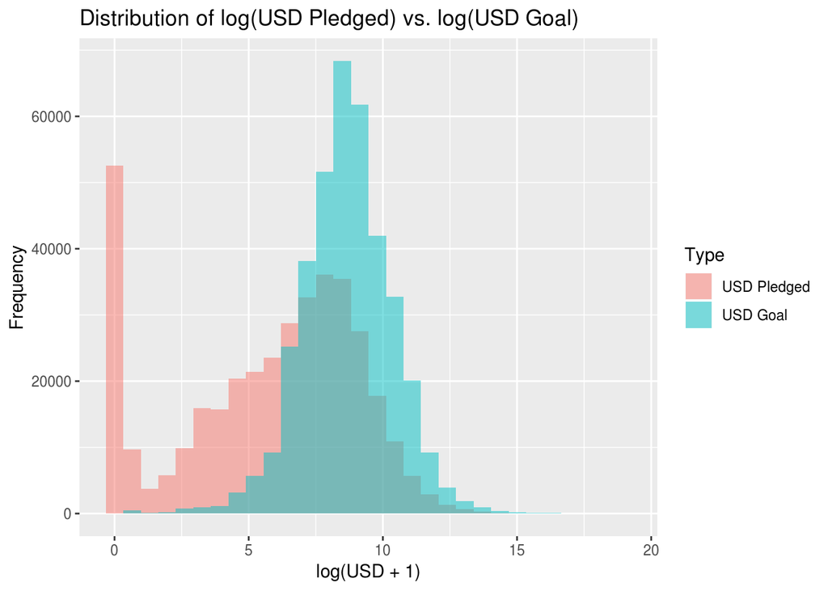

USD Goal appears to be relatively normally distributed. USD Pledged on the other hand has a bimodal distribution, with a tall left peak, which would represent projects that received either little or no funding. The approximate centre of the distribution of USD Pledged is located to the left side of the distribution of USD Goal, which tell us that many projects did not receive the required funding that they were looking for.

### What was the strongest relationship you found?

Technology, Design and games have received the highest amount of funding even though there is huge risk and have a lower success rate involved in them and backers tend to still give them because these categories tend to provide innovative technology products.

# Multivariate Plots Section

### Average amount Pledged per Backer on each Category

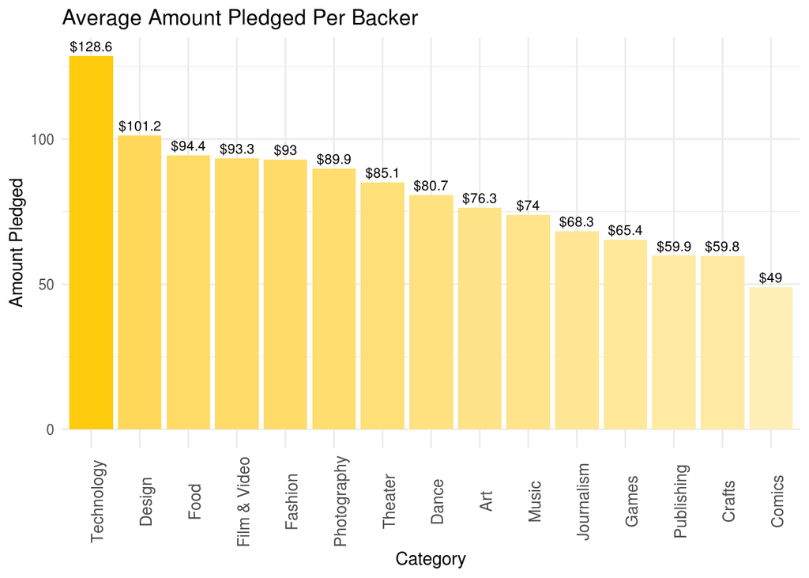

Technology has the highest amount pledged whereas, comics and crafts has the lower average amount. Technology has twice the amount of Games even though games is the most funded category. Journalism and Dance have a higher average amount but they were at the bottom when it came to total funding.

### Number of Backers per category and their success ratio.

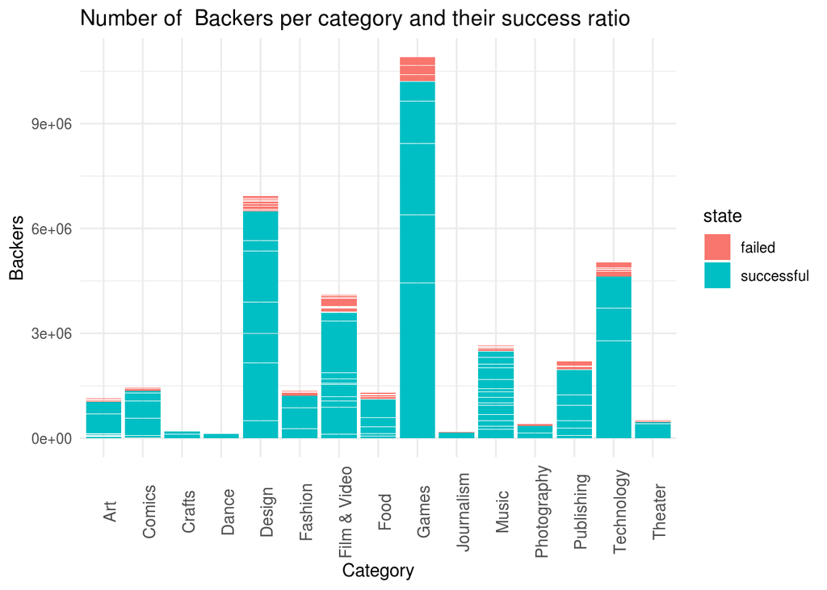

Games is not only the top category to get highest fundings but it alos has lot of backers(people) and their success ratio to backers is good. Design and Technology are the next with to get lot of people. Journalism, Dance and Crafts have the least backers and their success to backers ratio is the best, they have almost tto no failure.

### Project Success Ratio by country and category

Since US has almost 80% of the projects let’s compare US and Non US projects.

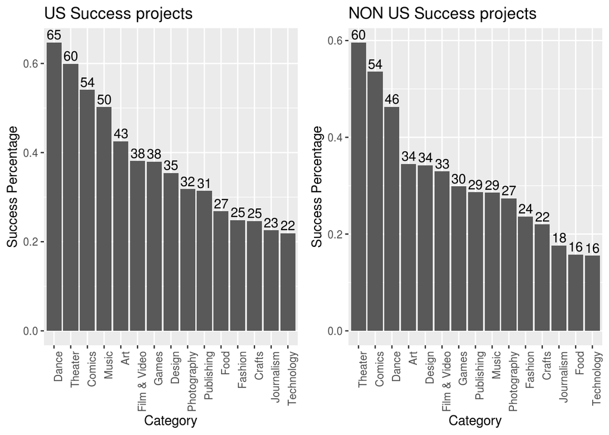

# Multivariate Analysis

Technology has twice the amount of Games even though games is the most funded category. Journalism and Dance have a higher average amount but they were at the bottom when it came to total funding.

### Were there any interesting or surprising interactions between features?

Games is not only the top category to get highest fundings but it alos has lot of backers(people) and their success ratio to backers is good.

# Final Plots and Summary

### Number of Projects per year

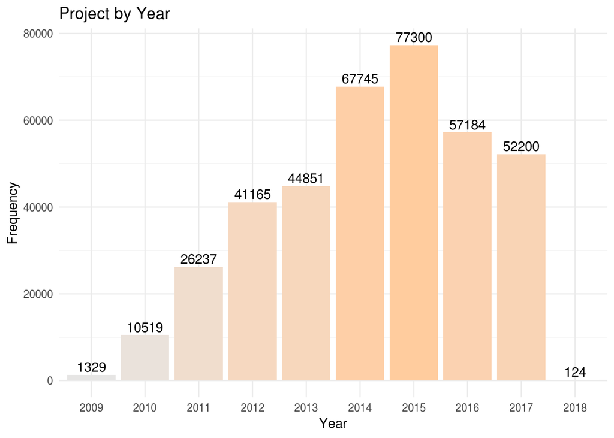

### Description One

Kickstarter started in 2009, we can see a huge rise in growth of projects during 2014 and 2015. Since, 2016 there is a decrease in the number of projects, we can’t predict whether this trend will continue because we don’t have enough data.

### Success and Failure of projects by year

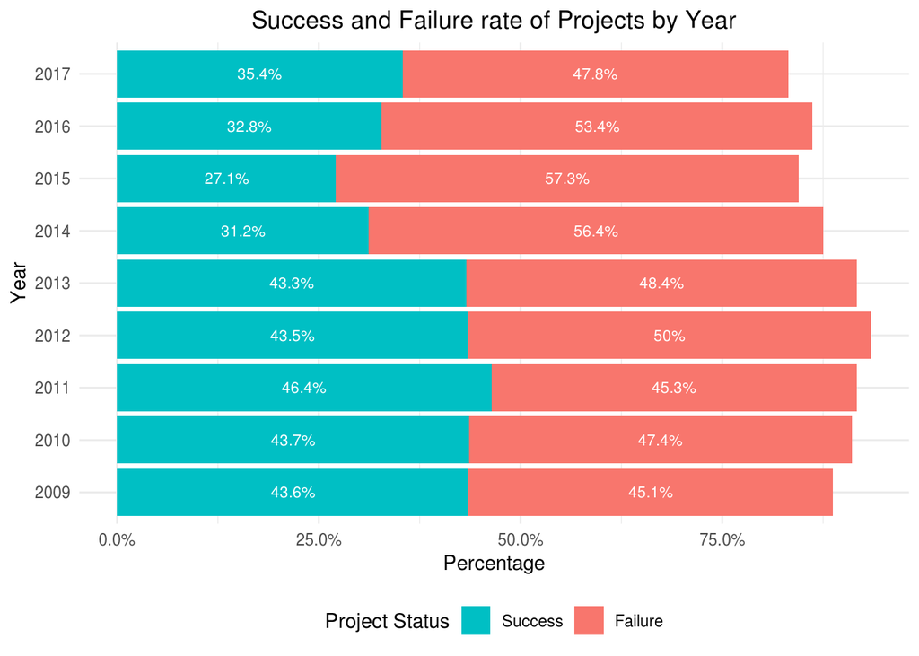

### Description Two

From the first plot we saw that there was a decrease in the number of projects per year, and in this plot we can see that 23014 and 2015 has the highest failure rate, while during 2016 and 2017 the success rate is been increasing. This tells us that only serious people are getting into kickstarter and the hype of startup or crowd funding is decreased over years.

### Amount Funded and Success rate by categories

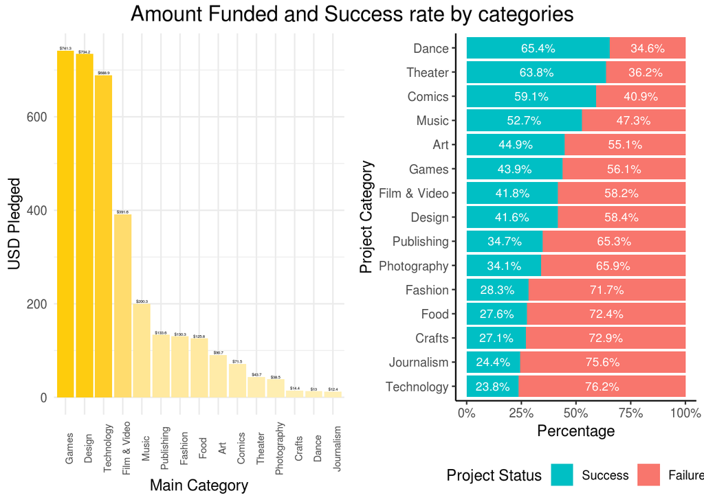

### Description Three

Games, Design and Technology have received the highest funding while Crafts, Dance and Journalism have received the lowest among all. But, Dance, Theater and Comics of all have a higher success rate while Technology has the lowest success rate, This might be because Dance, Theater and Comics have lower risks than Technology, But that’s not the same with Journalism or Crafts. Even Games and Design doesn’t have the success rate as of Dance or Theater but they are at the top and people seem to keep funding Games, Technology and Design because they tend to provide new and innovative things while Dance and Theater are just pure Entertainment, The reason for lower success rate of Journalism might be that not many people of this generation are intreseted in journalism and depend heavily on social networks for news and updates tham regular media.

# Reflection

The one thing that surprised me the most was the huge success rate in categories like Dance and Theater, and even though Technology, Games and deaign might not have a huge success rate people still fund them.

For future work, exploring projects that fell short of their goal, projects that were well funded and got suspended and building a model that depicts the number of backers and also how far or short will the project get funded.

The following conclusions are not certain, there may be issues with this methodology and we would need to address them to get a more definite result. The currency rate keeps on changing from time to time and we don’t know when these were converetd to USD. We would need more data, more metrics and better statistical tests to confirm the following findings; but the data is rich enough and the metric good enough to warrant further study.